# 02-locus-HWE-evaluation

Diana Baetscher

2023-03-30

Using the complete dataset to evaluate HWE across loci and populations in the baseline.

Updates: use the NAs explicit genos file. Don’t filter loci based on missing data at this point. Just look at reference pops for evaluating HWE.

Evaluating the loci that we’re using for self-assignment and bycatch assignment. These were originally derived from lcWGS data and the microhaplotype results suggest that the real variation present is potentially quite different. Initially, I should probably just focus on the baseline genotypes rather than including everything.

To evaluate the markers, I need to subset the reference baseline genotypes for just the minimal amount of missing data.

```r
library(tidyverse)
library(adegenet)
library(radiator)
library(DescTools)
# read in rds file with genotypes
genos_long <- read_rds("../data/processed/called_genos_na_explicit.rds")

# just select the reference samples based on metadata
samplesheets <- read_rds("../data/processed/metadata_bycatch_and_reference_20230330.rds")

reference_samples <- samplesheets %>%
  filter(Sample_Plate %in% c("BFAL001", "BFAL002") &
           !is.na(Location),
         !`Loc-Abbr` %in% c("Oahu", "Kauai, Kilauea")) %>%
  arrange(sampleID) %>%
  select(sampleID, gtseq_run, id, Location, `Loc-Abbr`)

# combine the genotypes with the reference
ref_genos <- reference_samples %>%
  left_join(., genos_long, by = c("gtseq_run", "id"))
```

Deal explicitly with duplicate samples:

## Some initial filters

### Take highest read-depth call for multiply-genotyped DNA_IDs

I’m not sure if there are any of these, but best to leave it in here…

Now, here is a harder operation: if an individual is multiply-genotyped, take the genotype with the highest total read depth.

```r
# slow-ish function to get the total read depth column
tdepth <- function(a, d) {
  if(any(is.na(a))) {
    return(NA)
  }
  if(a[1]==a[2]) {
    return(d[1])
  } else {
    return(d[1] + d[2])
  }

}
# this takes the highest read-depth instance of each duplicately-genotyped individual.
geno_one_each <- ref_genos %>%
  group_by(sampleID, locus, gtseq_run) %>%
  mutate(total_depth = tdepth(allele, depth)) %>%
  ungroup() %>%
  arrange(sampleID, locus, total_depth, gtseq_run, depth) %>%
  group_by(sampleID, locus) %>%
  mutate(rank = 1:n()) %>% # this ranks all alleles for a given individual by depth
  ungroup() %>%
  filter(rank <= 2) # this takes the top ranked alleles and should remove duplicates


# how many samples now?
geno_one_each %>%
  filter(!is.na(sampleID)) %>%
  group_by(sampleID) %>%
  select(sampleID, gtseq_run, id) %>%
  unique() %>%
  tally()
```

```
## # A tibble: 151 x 2
##    sampleID     n
##    <chr>    <int>
##  1 12-0155      1
##  2 12-0270      1
##  3 12-0271      1
##  4 12-0371      1
##  5 12-0372      1
##  6 12-0381      1
##  7 13-0991      1
##  8 13-1187      1
##  9 13-1198      1
## 10 14-0454      1
## # ... with 141 more rows
```

Take a look at missing data overall:

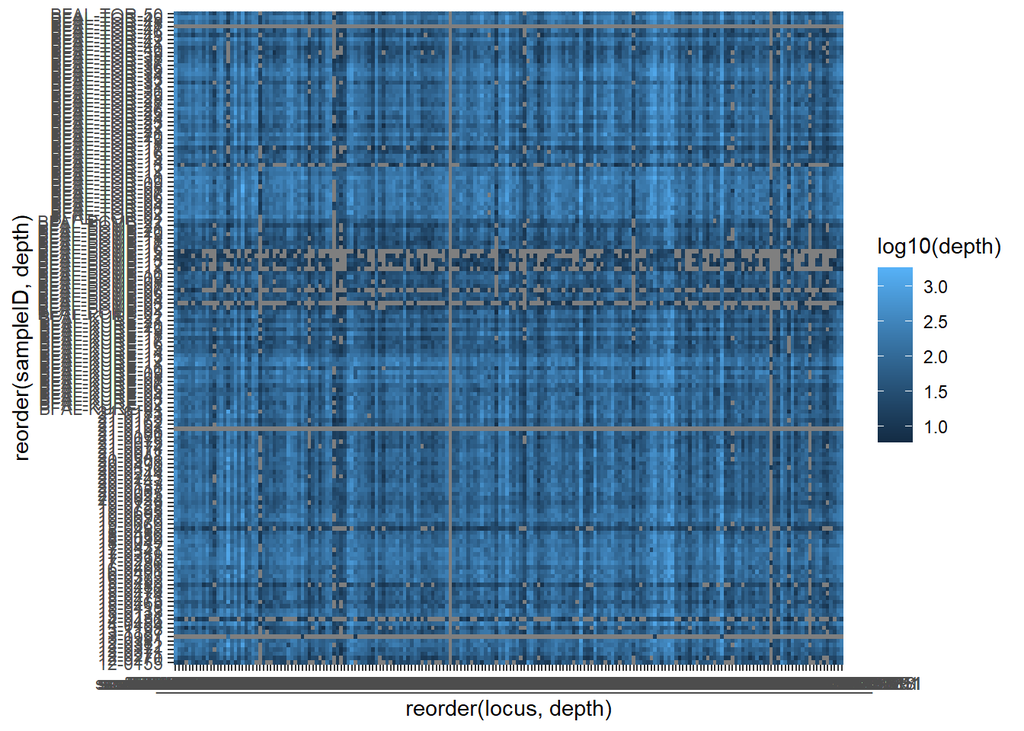

```r
geno_one_each %>%
  ggplot(aes(x = reorder(locus, depth), y = reorder(sampleID, depth), fill = log10(depth))) +
  geom_tile()
```

Deal with missing data:

## Missing data in loci

How many loci and how many alleles?

```r
# alleles
geno_one_each %>%
  filter(!is.na(allele)) %>%
  select(locus, allele) %>%
  unique()
```

```
## # A tibble: 458 x 2
##    locus                allele
##    <chr>                <chr>
##  1 scaffold_0_4543438   GGG
##  2 scaffold_0_4543438   GGA
##  3 scaffold_1_5556176   CT
##  4 scaffold_10_1333563  G
##  5 scaffold_10_1333563  A
##  6 scaffold_1050_36334  T
##  7 scaffold_1053_177405 A
##  8 scaffold_1078_116737 GC
##  9 scaffold_11_3057945  C
## 10 scaffold_115_2200290 C
## # ... with 448 more rows
```

```r
# loci
geno_one_each %>%
  filter(!is.na(allele)) %>%
  select(locus, allele) %>%
  unique() %>%
  group_by(locus) %>%
  tally() %>%
  arrange(desc(n))
```

```
## # A tibble: 189 x 2
##    locus                    n
##    <chr>                <int>
##  1 scaffold_1226_115783     6
##  2 scaffold_1589_18141      5
##  3 scaffold_316_437138      5
##  4 scaffold_33_2811656      5
##  5 scaffold_48_3128896      5
##  6 scaffold_75_1184494      5
##  7 scaffold_0_4543438       4
##  8 scaffold_1164_119437     4
##  9 scaffold_127_1105814     4
## 10 scaffold_15_2923659      4
## # ... with 179 more rows
```

In the reference, 458 alleles across 189 loci with 1-6 alleles per locus.

Some individuals are missing all their data, and some loci are missing all their data. Beginning with loci:

```r
# missing data across loci
locs_to_toss <- geno_one_each %>%
  group_by(locus) %>%
  mutate(missingness = ifelse(is.na(allele), 1, 0)) %>%
  summarise(sum(missingness)) %>% # 189 loci x2 = total
  filter(`sum(missingness)`>151) %>% # more than 50% missing data (given 151 individuals)
  select(locus) # drop those loci for now and see how the assignment goes

# just the keepers
genos_locs_filtered <- geno_one_each %>%
  anti_join(., locs_to_toss)
```

Remove these 4 loci because of too much missing data in the reference samples.

## Missing data in individuals

Total number of loci = 185

Total number of samples = 151

```r
inds_to_toss <- genos_locs_filtered %>%
  group_by(sampleID) %>%
  mutate(missingness = ifelse(is.na(allele), 1, 0)) %>%
  summarise(sum(missingness)) %>%
  arrange(desc(`sum(missingness)`)) %>%
  #filter(`sum(missingness)` > 47) # remove samples with >25% missing data
 filter(`sum(missingness)` > 19) # remove samples with >10% missing data

# just the keepers
genos_locs_ind_filtered <- genos_locs_filtered %>%
  anti_join(., inds_to_toss)
```

23 samples removed with >10% missing data.

Now look at missing data:

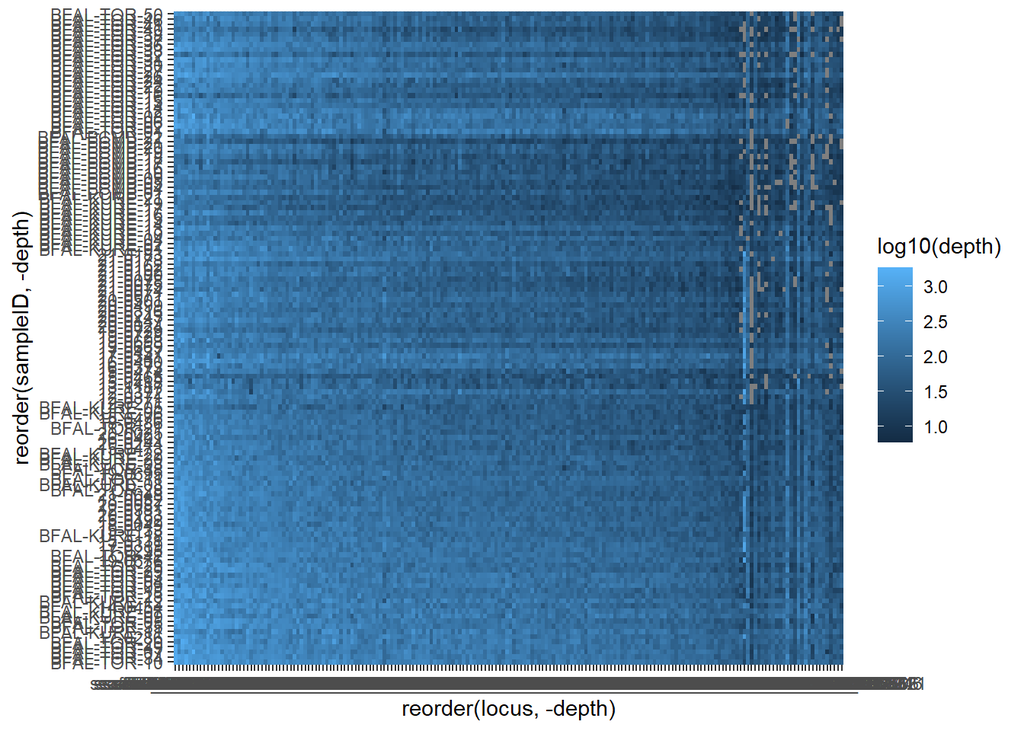

```r
genos_locs_ind_filtered %>%
  ggplot(aes(x = reorder(locus, -depth), y = reorder(sampleID, -depth), fill = log10(depth))) +
  geom_tile()
```

Much better. Now move forward from here.